# Lab 1

Dastin Scott

2025-08-31

# Task 1

```r
getwd()
```

```
## [1] "C:/RPackages/MATH4753F25dastin/Labs/Lab 1"
```

# Task 2

```r
ddt <- read.csv("DDT.csv")
head(ddt)
```

```
##   RIVER MILE  SPECIES LENGTH WEIGHT DDT
## 1   FCM    5 CCATFISH   42.5    732  10
## 2   FCM    5 CCATFISH   44.0    795  16
## 3   FCM    5 CCATFISH   41.5    547  23
## 4   FCM    5 CCATFISH   39.0    465  21
## 5   FCM    5 CCATFISH   50.5   1252  50
## 6   FCM    5 CCATFISH   52.0   1255 150
```

# Task 3

**What are the qualitative variables in “ddt”?**

“RIVER and”SPECIES” are the qualitative variable because they aren’t numeric.

**What are the quantitative variables in “ddt”?**

“MILE”, “LENGTH”, “WEIGHT”, and “DDT” are the quantitative variables because they are numeric.

**How many SPECIES are in the ddt data set?**

```r
length(unique(ddt$SPECIES))
```

```
## [1] 3
```

**Subset the ddt data set so that we see only the observations with SPECIES, LMBASS and WEIGHT bigger than 800gms**

```r
subset_LMBASS_800 <- subset(ddt, SPECIES == "LMBASS" & WEIGHT > 800)
subset_LMBASS_800
```

```
##     RIVER MILE SPECIES LENGTH WEIGHT DDT
## 141   TRM  345  LMBASS     30    856 2.2
## 144   TRM  345  LMBASS     36   1433 1.9
```

**Subset the ddt data set so that we see only those observations where the RIVER is SCM and DDT bigger than 4.0**

```r
subset_SCM_DDT4 <- subset(ddt, RIVER == "SCM" & DDT > 4.0)
subset_SCM_DDT4
```

```
##    RIVER MILE  SPECIES LENGTH WEIGHT DDT
## 16   SCM    1 CCATFISH     45    984 9.1
## 17   SCM    1 CCATFISH     43    965 7.8
## 18   SCM    1 CCATFISH     45   1084 4.1
```

# Task 4

**Q.1 Find the mean length of fish in the ddt data frame!**

```r
  mean(ddt$LENGTH)
```

```
## [1] 42.8125
```

Ans. 42.8125

**Q.2 What is the standard deviation of the weight of fish in the ddt data frame?**

```r
  sd(ddt$WEIGHT)
```

```
## [1] 376.5461
```

Ans. 376.5461118

**Q3. Is this the plot of LENGTH vs WEIGHT from the ddt data frame?**

Ans. No, the plot given was WEIGHT vs LENGTH, the plot below is LENGTH vs WEIGHT

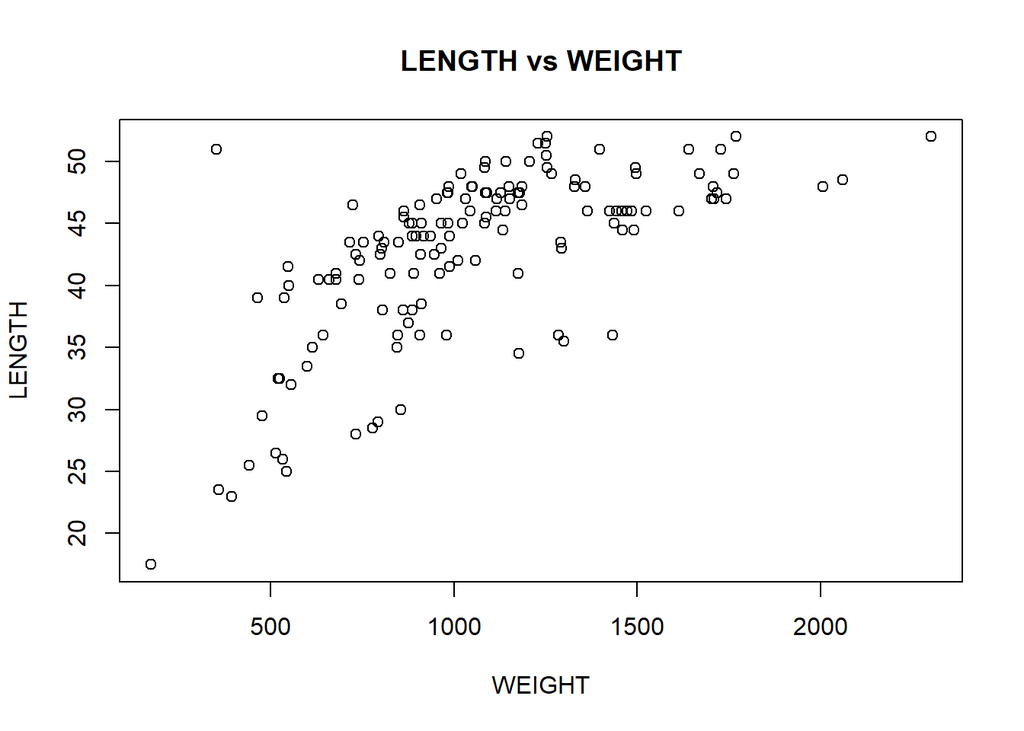

```r
plot(LENGTH ~ WEIGHT, data = ddt, main = "LENGTH vs WEIGHT")
```

Q4. If v=1:20 what is the last value of v/20?

```r
v <- 1:20
tail(v/20, 1)
```

```
## [1] 1
```

Ans. 1

# Task 5

```r
# table of rivers
tab_river <- with(ddt, table(RIVER))
tab_river
```

```
## RIVER
## FCM LCM SCM TRM
##   6   6   6 126
```

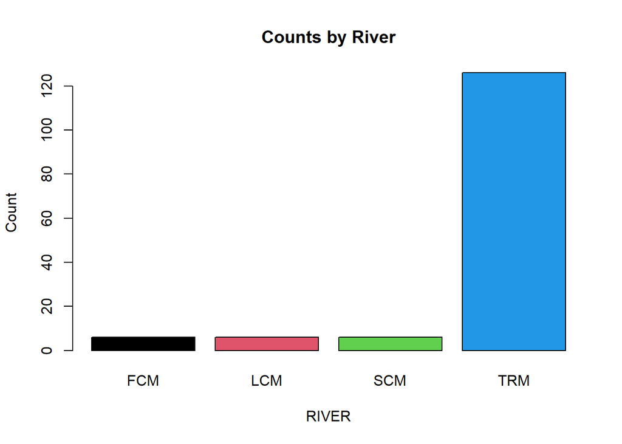

```r
# barplot of rivers
barplot(tab_river, main = "Counts by River", xlab = "RIVER", ylab = "Count", col = 1:length(tab_river))
```

```r
# rivers x species
tab_river_species <- with(ddt, table(RIVER, SPECIES))
tab_river_species
```

```
##      SPECIES
## RIVER CCATFISH LMBASS SMBUFFALO
##   FCM        6      0         0
##   LCM        6      0         0
##   SCM        6      0         0
##   TRM       78     12        36
```

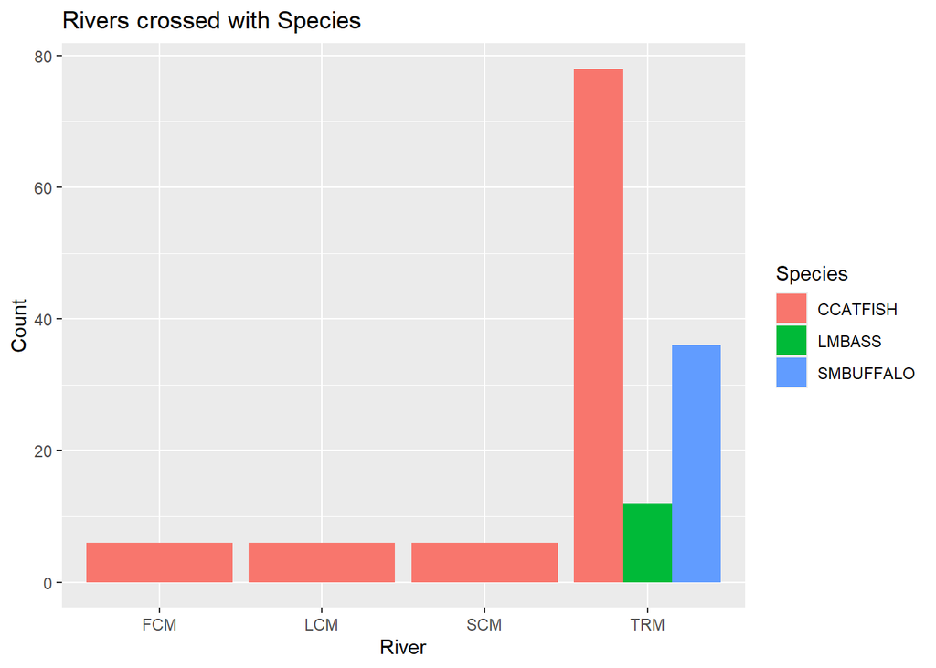

```r
# barplot rivers x species
library(ggplot2)
ggplot(ddt, aes(x = RIVER, fill = SPECIES)) +
  geom_bar(position = "dodge") +
  labs(title = "Rivers crossed with Species",
       x = "River",
       y = "Count",
       fill = "Species")
```

# Task 6

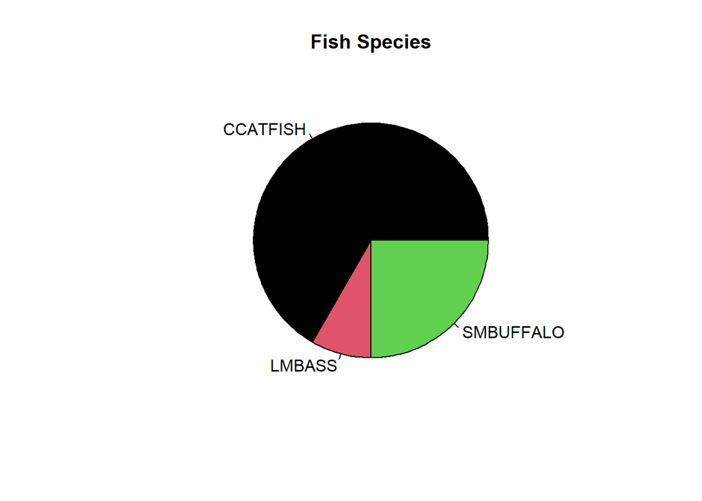

```r
# pie chart of species
tab_species <- with(ddt, table(SPECIES))
pie(tab_species, main = "Fish Species", col = 1:length(tab_species))
```

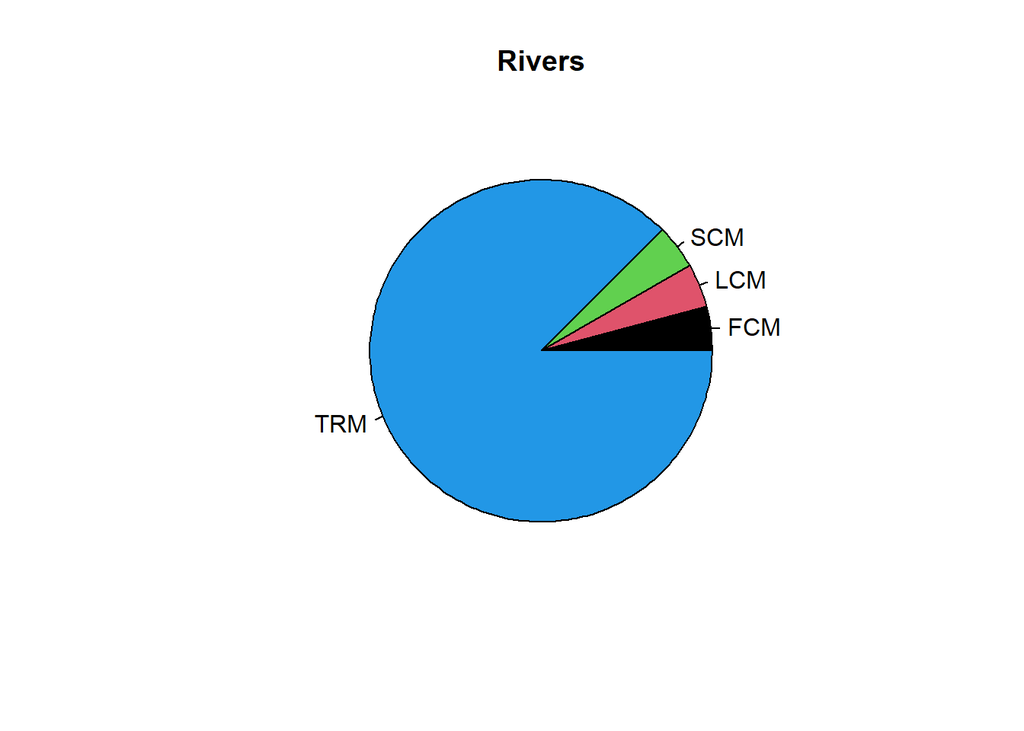

```r
# pie chart of rivers
pie(tab_river, main = "Rivers", col = 1:length(tab_river))
```

# Task 7

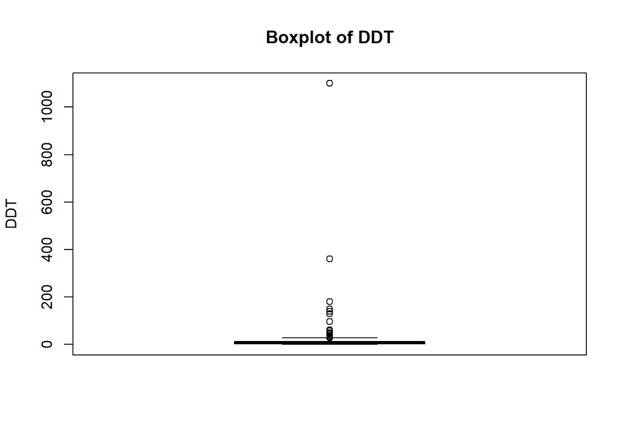

```r
#boxplot ddt
boxplot(ddt$DDT, main = "Boxplot of DDT", ylab = "DDT", col = "lightgray")
```

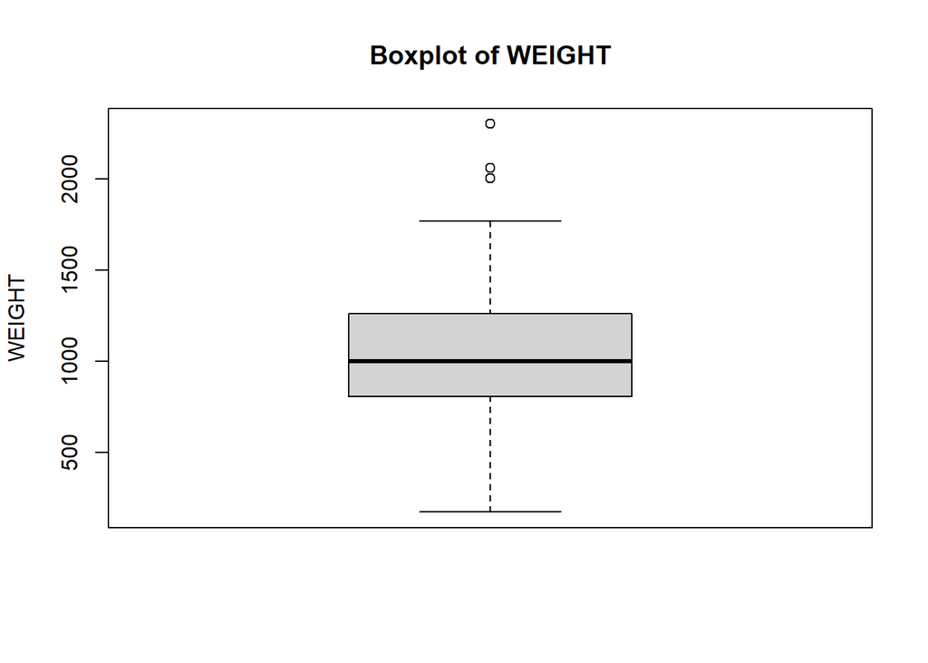

```r
#boxplot weight
boxplot(ddt$WEIGHT, main = "Boxplot of WEIGHT", ylab = "WEIGHT", col = "lightgray")
```

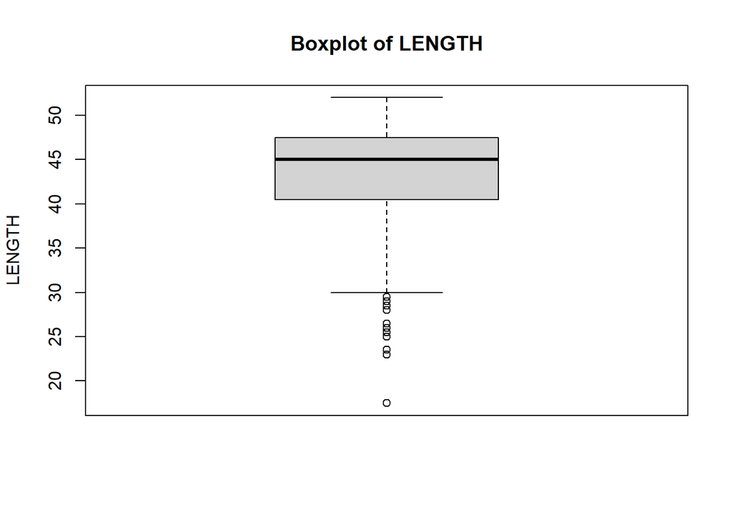

```r
#boxplot length
boxplot(ddt$LENGTH, main = "Boxplot of LENGTH", ylab = "LENGTH", col = "lightgray")
```

# Task 8

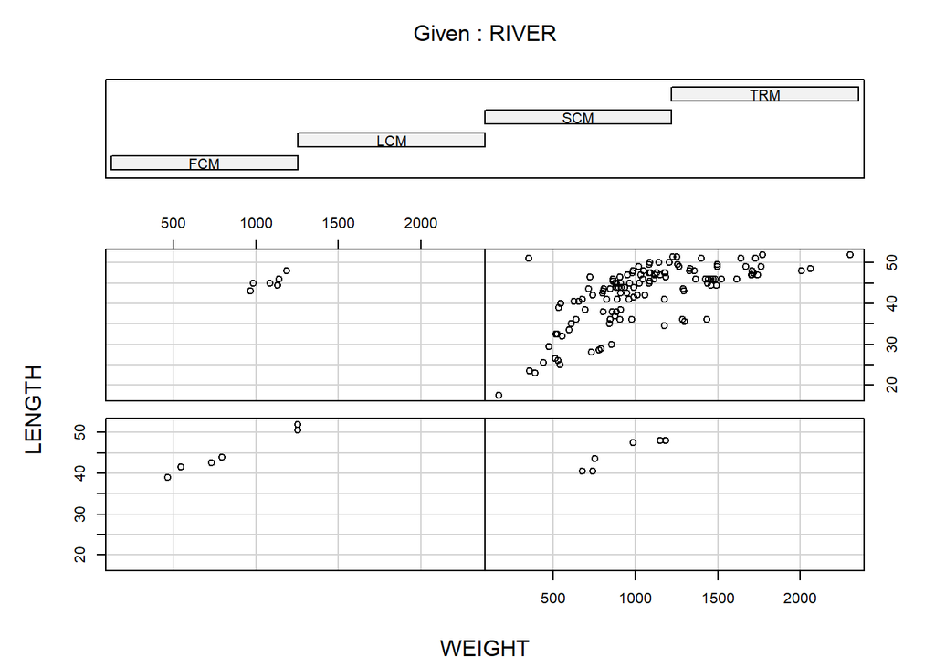

```r
#coplot length v weight given river
coplot(LENGTH ~ WEIGHT | RIVER, data = ddt, xlab = "WEIGHT", ylab = "LENGTH")
```

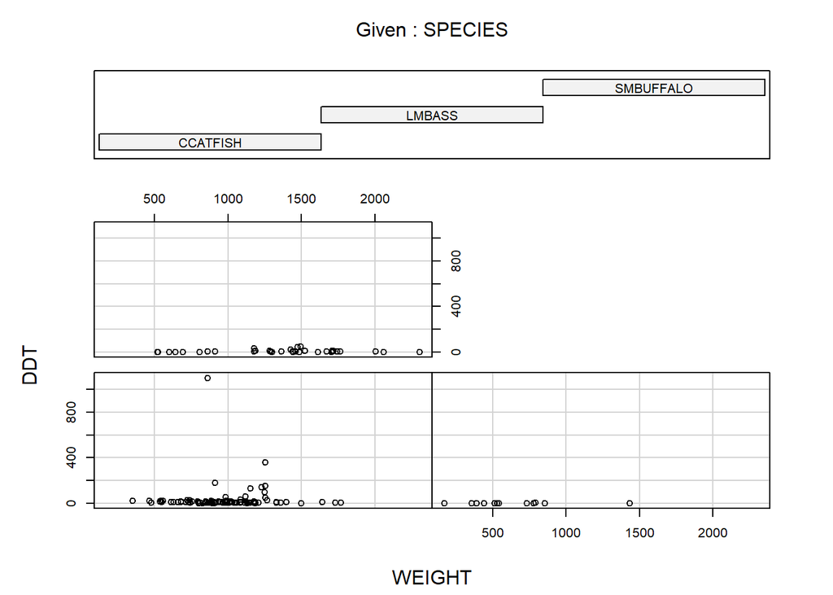

```r
#coplot ddt v weight given species
coplot(DDT ~ WEIGHT | SPECIES, data = ddt, xlab = "WEIGHT", ylab = "DDT")
```

# Task 9

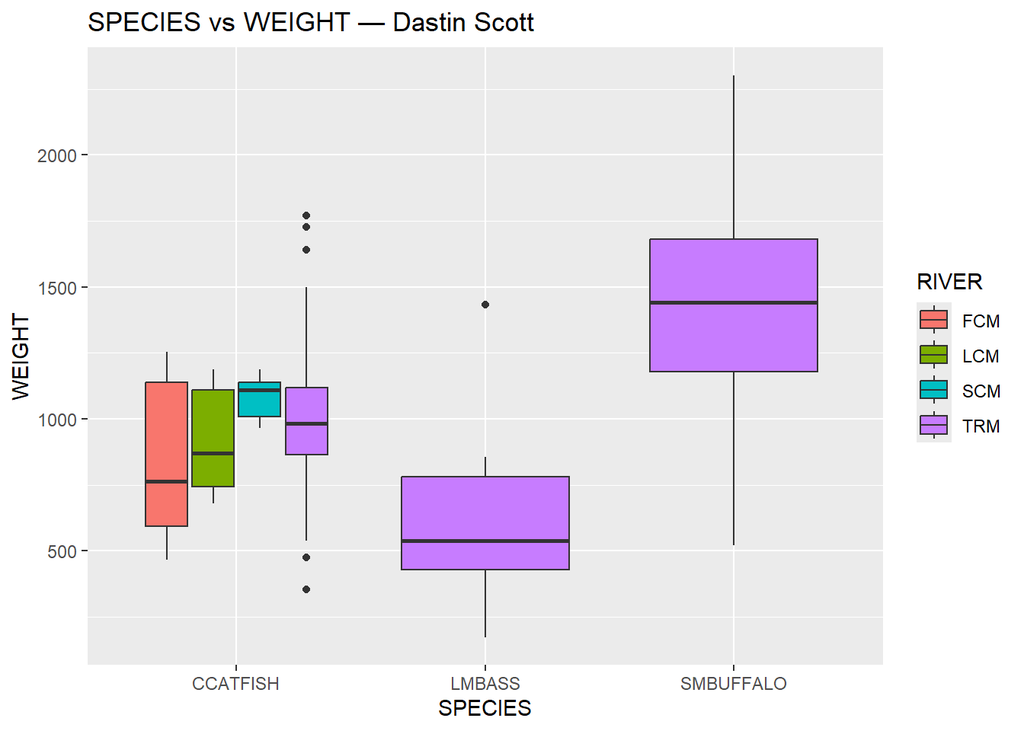

```r
library(ggplot2)

#boxplot
ggplot(ddt, aes(x = SPECIES, y = WEIGHT, fill = RIVER)) +
  geom_boxplot() +
  ggtitle("SPECIES vs WEIGHT — Dastin Scott") +
  labs(x = "SPECIES", y = "WEIGHT")
```

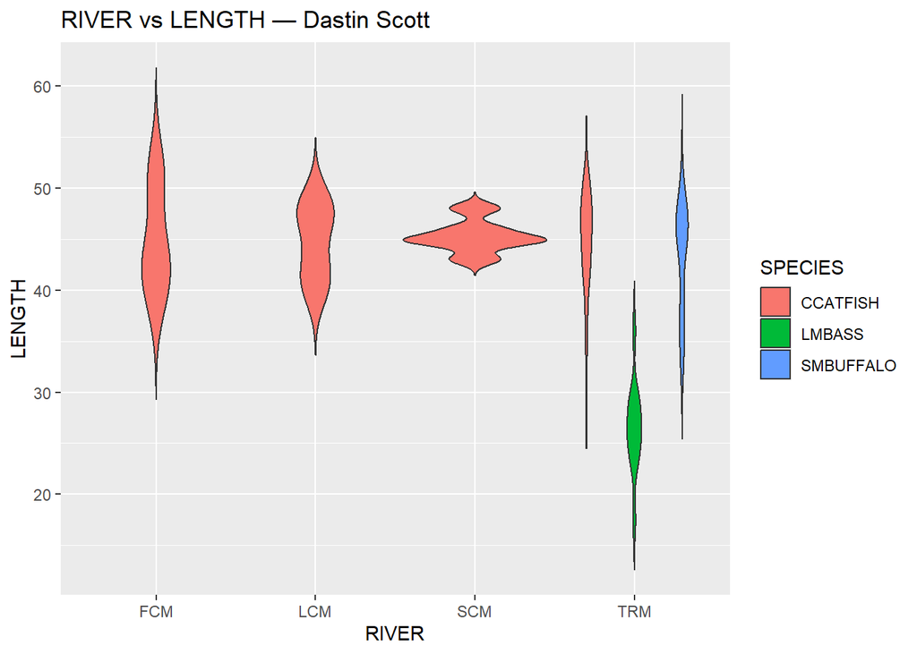

```r
#violin plot
ggplot(ddt, aes(x = RIVER, y = LENGTH, fill = SPECIES)) +
  geom_violin(trim = FALSE) +
  ggtitle("RIVER vs LENGTH — Dastin Scott") +
  labs(x = "RIVER", y = "LENGTH")
```

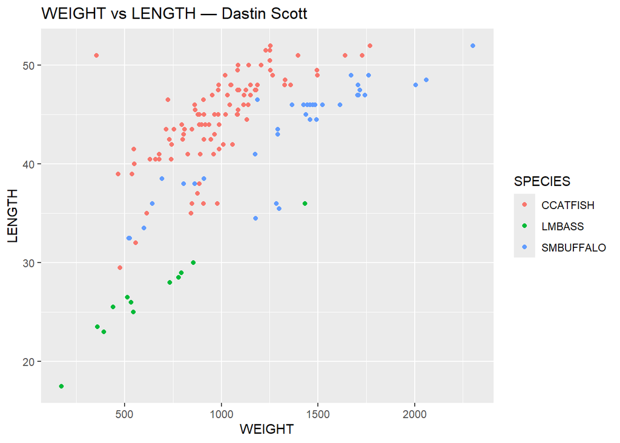

```r
#scatter plot
ggplot(ddt, aes(x = WEIGHT, y = LENGTH, color = SPECIES)) +
  geom_point() +
  ggtitle("WEIGHT vs LENGTH — Dastin Scott") +
  labs(x = "WEIGHT", y = "LENGTH")
```